## Goal

Our goal will be to reproduce an equivalence table relating year 2000 Bay Area Census Tracts to MTC’s Transportation Analysis Zones (TAZ).

The long-term goal is to be able to reproduce this lookup table for any census geographies. It may also be useful to reproduce the table for other kinds of geographies (e.g. jurisdictions).

## Year 2000 TAZ/Tract Lookup Data

Lets inspect the lookup table that we want to reproduce.

```r
library(readr)
Tract_zone_2000 <- read_csv("https://s3-us-west-2.amazonaws.com/equivalence/Tract_zone_2000.csv")
## Parsed with column specification:
## cols(
##   Tract = col_integer(),
##   rtaz1 = col_integer(),
##   rtaz2 = col_integer(),
##   rtaz3 = col_integer(),
##   rtaz4 = col_integer(),
##   rtaz5 = col_integer()
## )

knitr::kable(head(Tract_zone_2000))
```

| Tract | rtaz1 | rtaz2 | rtaz3 | rtaz4 | rtaz5 |
| --- | --- | --- | --- | --- | --- |
| 10100 | 41 | NA | NA | NA | NA |
| 10200 | 40 | NA | NA | NA | NA |
| 10300 | 39 | NA | NA | NA | NA |
| 10400 | 38 | NA | NA | NA | NA |
| 10500 | 22 | 23 | NA | NA | NA |
| 10600 | 37 | NA | NA | NA | NA |

So, we’ll need to look up the ID for all TAZs that relate to a Census Tract, by ID.

## TAZ Data

We download and read TAZ Data from MTC’s open data portal.

```r
library(sf)
## Linking to GEOS 3.6.2, GDAL 2.2.3, proj.4 4.9.3
library(dplyr)
taz1454 <- st_read("https://opendata.arcgis.com/datasets/b85ba4d43f9843128d3542260d9a2f1f_0.geojson")
## Reading layer `b85ba4d43f9843128d3542260d9a2f1f_0' from data source `https://opendata.arcgis.com/datasets/b85ba4d43f9843128d3542260d9a2f1f_0.geojson' using driver `GeoJSON'
## Simple feature collection with 1454 features and 5 fields
## geometry type:  MULTIPOLYGON
## dimension:      XY
## bbox:           xmin: -123.5337 ymin: 36.89416 xmax: -121.2082 ymax: 38.86425
## epsg (SRID):    4326
## proj4string:    +proj=longlat +datum=WGS84 +no_defs

knitr::kable(table(st_is_valid(taz1454)))
```

| Var1 | Freq |
| --- | --- |
| FALSE | 1 |
| TRUE | 1453 |

One of the TAZ geometries is “invalid”. this is probably not important but could be, so lets look into it

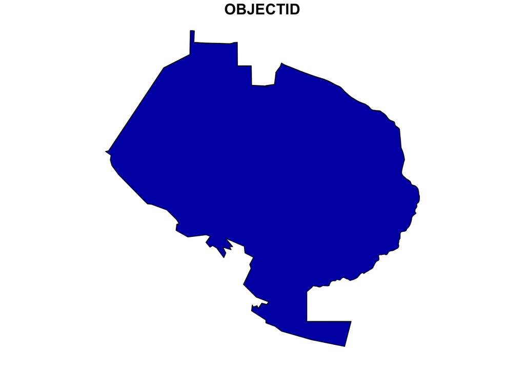

```r
plot(taz1454[!st_is_valid(taz1454),], max.plot=1)
```

geom looks OK visually lets make note of the taz_id to review later

```r
invalid_taz_id <- taz1454[!st_is_valid(taz1454),]$TAZ1454
```

note: this is not a data type issue per se (geojson, M drive, etc) i also checked the source shapefile on M and it has the same invalid geometry (plus another additional one) arcmap does not see any of these geometries as invalid

## Census Data

clean up the headers and data

```r
taz1454 <- dplyr::select(taz1454,TAZ1454)
taz1454 <- dplyr::rename(taz1454, taz = TAZ1454)
print(head(taz1454))
## Simple feature collection with 6 features and 1 field
## geometry type:  MULTIPOLYGON
## dimension:      XY
## bbox:           xmin: -121.8723 ymin: 37.27415 xmax: -121.8056 ymax: 37.31855
## epsg (SRID):    4326
## proj4string:    +proj=longlat +datum=WGS84 +no_defs
##   taz                       geometry
## 1 566 MULTIPOLYGON (((-121.8681 3...
## 2 565 MULTIPOLYGON (((-121.8588 3...
## 3 573 MULTIPOLYGON (((-121.8124 3...
## 4 571 MULTIPOLYGON (((-121.806 37...
## 5 576 MULTIPOLYGON (((-121.8279 3...
## 6 575 MULTIPOLYGON (((-121.8326 3...

taz1454 <- sf::st_transform(taz1454, crs=26910)
```

Join the geometries together.

```r
tt <- sf::st_join(tracts,taz1454)
tt <- as.data.frame(tt)
tt <- dplyr::select(tt,-geometry)
print(head(tt))
```

```
##        tract taz
## 871   505202 543
## 871.1 505202 545
## 871.2 505202 430
## 871.3 505202 433
## 871.4 505202 415
## 871.5 505202 431
```

Check the problem geom

```r
knitr::kable(tt[tt$taz==invalid_taz_id,])
```

|  | tract | taz |
| --- | --- | --- |
| 3844.2 | 346102 | 1102 |
| 3845.4 | 346101 | 1102 |
| 3847 | 355305 | 1102 |
| 3848.3 | 355304 | 1102 |
| 3849.3 | 355303 | 1102 |
| 3850.4 | 355302 | 1102 |
| 3851.5 | 355301 | 1102 |
| 3863.2 | 346201 | 1102 |
| 3874.8 | 338302 | 1102 |
| 3974.8 | 355106 | 1102 |
| 4005.9 | 355104 | 1102 |

### Output desired table format

Ok so its now time to format the tt table in the sparse matrix style format from the 2000 data

```r
tt$num <- ave(tt[['taz']],
              tt[['tract']],
              FUN = seq_along)

tt$header_string <- 'rtaz'

et <- tt %>%
  tidyr::unite("header_string",
                   header_string,
                   num) %>%
    tidyr::spread(header_string, taz)

knitr::kable(head(et))
```

| tract | rtaz_1 | rtaz_10 | rtaz_11 | rtaz_12 | rtaz_13 | rtaz_14 | rtaz_15 | rtaz_16 | rtaz_17 | rtaz_18 | rtaz_19 | rtaz_2 | rtaz_20 | rtaz_21 | rtaz_22 | rtaz_3 | rtaz_4 | rtaz_5 | rtaz_6 | rtaz_7 | rtaz_8 | rtaz_9 |
| --- | --- | --- | --- | --- | --- | --- | --- | --- | --- | --- | --- | --- | --- | --- | --- | --- | --- | --- | --- | --- | --- | --- |
| 010100 | 23 | NA | NA | NA | NA | NA | NA | NA | NA | NA | NA | 41 | NA | NA | NA | 39 | 40 | 38 | NA | NA | NA | NA |
| 010200 | 44 | NA | NA | NA | NA | NA | NA | NA | NA | NA | NA | 40 | NA | NA | NA | 34 | 43 | 45 | NA | NA | NA | NA |
| 010300 | 39 | NA | NA | NA | NA | NA | NA | NA | NA | NA | NA | 35 | NA | NA | NA | 40 | 34 | NA | NA | NA | NA | NA |
| 010400 | 39 | NA | NA | NA | NA | NA | NA | NA | NA | NA | NA | 37 | NA | NA | NA | 38 | 36 | NA | NA | NA | NA | NA |
| 010500 | 1 | NA | NA | NA | NA | NA | NA | NA | NA | NA | NA | 15 | NA | NA | NA | 23 | 22 | 41 | 37 | 24 | 38 | NA |
| 010600 | 37 | NA | NA | NA | NA | NA | NA | NA | NA | NA | NA | 25 | NA | NA | NA | 24 | 38 | 36 | NA | NA | NA | NA |

lets have a look at the first tract to see why that might be the case

## Inspect A single TAZ/Tract overlap

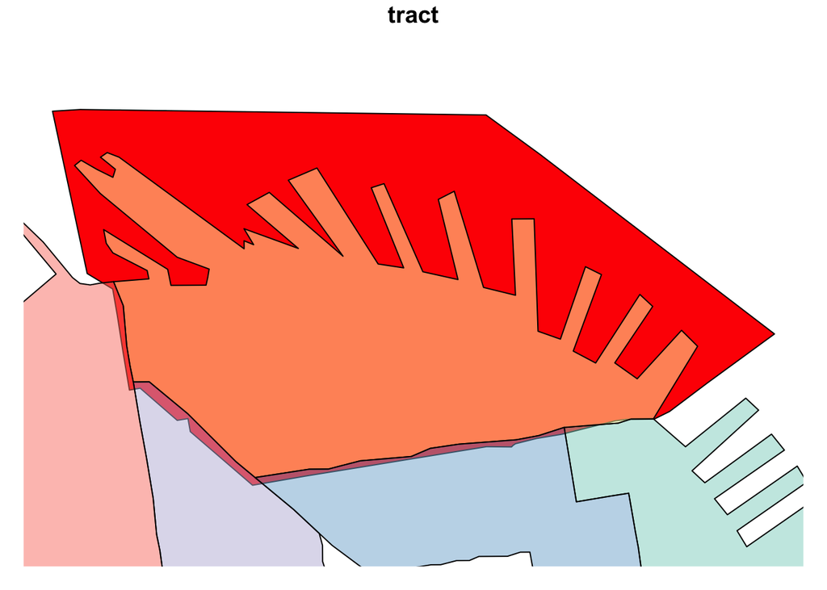

```r
tract1 <- tracts[tracts$tract=="010100",]

tazs1 <- taz1454[taz1454$taz %in%
                   tt[tt$tract=="010100",]$taz,]

plot(tract1, col="red", max.plot=1)

plot(tazs1,
     col = sf.colors(categorical = TRUE, alpha = .5),
     add=TRUE)
```

When we plot it, its clear that the taz extends slightly into nearby tracts

## TAZ/Tract Overlaps by Area

```r
intersection_df <- st_intersection(tract1,tazs1)
intersection_df$area <- st_area(intersection_df)

st_geometry(intersection_df) <- NULL

knitr::kable(intersection_df)
```

|  | tract | taz | area |
| --- | --- | --- | --- |
| 4649 | 010100 | 23 | 897.9859 m^2 |
| 4649.1 | 010100 | 41 | 779385.7507 m^2 |
| 4649.2 | 010100 | 39 | 11020.0877 m^2 |
| 4649.3 | 010100 | 40 | 4619.3630 m^2 |
| 4649.4 | 010100 | 38 | 12370.7476 m^2 |

Lets do a reasonable estimate of what the coverage rule should be and then compare it to the Year 2000 data, which were hand-checked.

```r
tracts$tract_area <- st_area(tracts)
intersection_df <- st_intersection(tracts,taz1454)
intersection_df$intersection_area <- st_area(intersection_df)

intersection_df$intersection_ratio <- intersection_df$intersection_area/intersection_df$tract_area
st_geometry(intersection_df) <- NULL
knitr::kable(head(intersection_df))
```

|  | tract | tract_area | taz | intersection_area | intersection_ratio |
| --- | --- | --- | --- | --- | --- |
| 938 | 503204 | 1414065 m^2 | 566 | 1400.6217 m^2 | 0.0009904934 1 |
| 1128 | 512020 | 1036961 m^2 | 566 | 6779.8343 m^2 | 0.0065381781 1 |
| 1274 | 503108 | 2271608 m^2 | 566 | 362.8064 m^2 | 0.0001597135 1 |
| 1275 | 503115 | 4465081 m^2 | 566 | 4343601.3391 m^2 | 0.9727933725 1 |
| 1282 | 503116 | 1214922 m^2 | 566 | 8480.0498 m^2 | 0.0069799130 1 |
| 1285 | 503103 | 6439091 m^2 | 566 | 5734.6109 m^2 | 0.0008905932 1 |

Looks like water features were clipped from the TAZ data and that messing with the area ratio.

Lets do the same for tracts.

```r
bay_water <- st_read("https://geo.nyu.edu/download/file/stanford-mb777jk0330-geojson.json")
## Reading layer `stanford-mb777jk0330-geojson' from data source `https://geo.nyu.edu/download/file/stanford-mb777jk0330-geojson.json' using driver `GeoJSON'
## Simple feature collection with 367 features and 6 fields
## geometry type:  MULTIPOLYGON
## dimension:      XY
## bbox:           xmin: -123.6336 ymin: 36.92222 xmax: -121.2531 ymax: 38.85059
## epsg (SRID):    4326
## proj4string:    +proj=longlat +datum=WGS84 +no_defs
bay_water <- bay_water[st_is_valid(bay_water),]
```

[output not shown]

```r
bay_water <- st_transform(bay_water, crs=26910)

st_erase = function(x, y) st_difference(x, st_union(st_combine(y)))
tracts <- st_erase(tracts,bay_water)
```

Now the ratios should allow for easier comparison

```r
tracts$tract_area <- st_area(tracts)
intersection_df <- st_intersection(tracts,taz1454)
intersection_df$intersection_area <- st_area(intersection_df)

st_geometry(intersection_df) <- NULL

intersection_df$intersection_ratio <- intersection_df$intersection_area/intersection_df$tract_area

knitr::kable(head(intersection_df))
```

[output not shown]

## Year 2000 Data method/rule for Overlap

Lets try to use the Year 2000 data to determine a rule for what acceptable taz/tract area overlap is.

One way to do this is to plot which spatial intersections were chosen for the Year 2000 data. Then we can back a proportion or area rule out of that and apply it.

```r
intersection_df_s <- intersection_df[,c('tract','taz')]

tract_zone_2000_dense <- reshape2::melt(Tract_zone_2000, id.vars = "Tract")

print(dim(tract_zone_2000_dense))
```

```
## [1] 7025    3
```

```r
intersection_df_s$tract <- as.integer(intersection_df_s$tract)

names(tract_zone_2000_dense) <- c('tract','string','taz')

compare_intersection_df <- left_join(intersection_df_s, tract_zone_2000_dense, by=c('tract','taz'),suffix=c('full_intersection','tz2000'))

table(compare_intersection_df$string)
```

```
##
## rtaz1 rtaz2 rtaz3 rtaz4 rtaz5
##  1405    29    11     5     3
```

```r
sum(as.vector((table(compare_intersection_df$string))))
```

```
## [1] 1453
```

So there are 3 tracts with 5 intersecting TAZ’s and there are a total of 1453 intersections.

Lets take just the joins from 2000 and then replicate them and push them as topojson to github so we can inspect them.

```r
intersection_df_s$tract <- as.integer(intersection_df_s$tract)
intersection_df_sf <- st_intersection(tracts,taz1454)
intersection_df_sf$tract <- as.integer(intersection_df_sf$tract)
intersection_df$intersection_area <- st_area(intersection_df_sf)


just_2000_joins <- compare_intersection_df[!is.na(compare_intersection_df$string),]
not_2000_joins <- compare_intersection_df[is.na(compare_intersection_df$string),]

replicate_2000_as_sf <- right_join(intersection_df_sf,just_2000_joins,by=c('tract','taz'),suffix = c('intersection_df','just_2000'))
slivers_2000_as_sf <- right_join(intersection_df_sf,not_2000_joins,by=c('tract','taz'),suffix = c('intersection_df','just_2000'))

library(geojsonio)
#st_write(replicate_2000_as_sf,path="Tract_zone_2000.geojson")
topojson_write(replicate_2000_as_sf,file="replicate_2000_as_sf.topojson",convert_wgs84 = TRUE)
## Success! File at replicate_2000_as_sf.topojson
## <topojson-file>
##   Path:       replicate_2000_as_sf.topojson
##   From class: sfc

#st_write(replicate_2000_as_sf,path="Tract_zone_2000.geojson")
topojson_write(slivers_2000_as_sf,file="slivers_2000_as_sf.topojson",convert_wgs84 = TRUE)
## Success! File at slivers_2000_as_sf.topojson
## <topojson-file>
##   Path:       slivers_2000_as_sf.topojson
##   From class: sfc
```

## Cartographic Review of Year 2000 intersections

Click [here](https://github.com/BayAreaMetro/Data-And-Visualization-Projects/blob/master/census_examples/slivers_2000_as_sf.topojson) to see the TAZ/Tract intersections from Year 2000 that were rejected.

Click [here](https://github.com/BayAreaMetro/Data-And-Visualization-Projects/blob/master/census_examples/replicate_2000_as_sf.topojson) to see the TAZ/Tract intersections from Year 2000 that were accepted.

## Distribution Review of Year 2000 intersections

What proportion of overlap was commonly used when joining TAZ's and tracts in these data?

We can also answer this question by looking at the distribution of the proportion of the intersection of a TAZ/Tract to the total tract area.

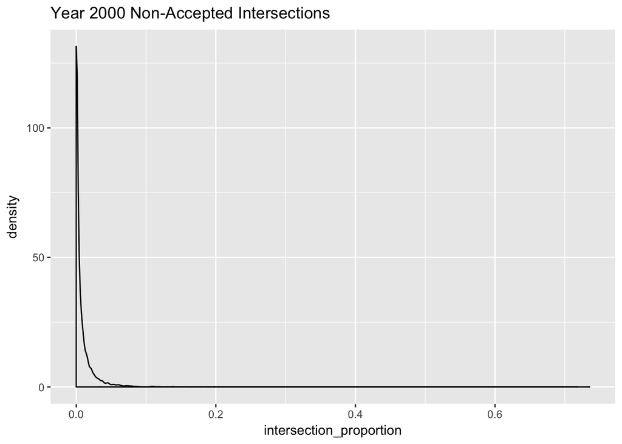

```r
slivers_2000_as_sf$intersection_area <- as.numeric(st_area(slivers_2000_as_sf))
replicate_2000_as_sf$intersection_area <- as.numeric(st_area(replicate_2000_as_sf))

slivers_2000_as_sf$intersection_proportion <- as.numeric(slivers_2000_as_sf$intersection_area/slivers_2000_as_sf$tract_area)
replicate_2000_as_sf$intersection_proportion <- as.numeric(replicate_2000_as_sf$intersection_area/replicate_2000_as_sf$tract_area)

library(ggplot2)

ggplot(slivers_2000_as_sf, aes(intersection_proportion)) +
  geom_density() +
    labs(title = "Year 2000 Non-Accepted Intersections")
```

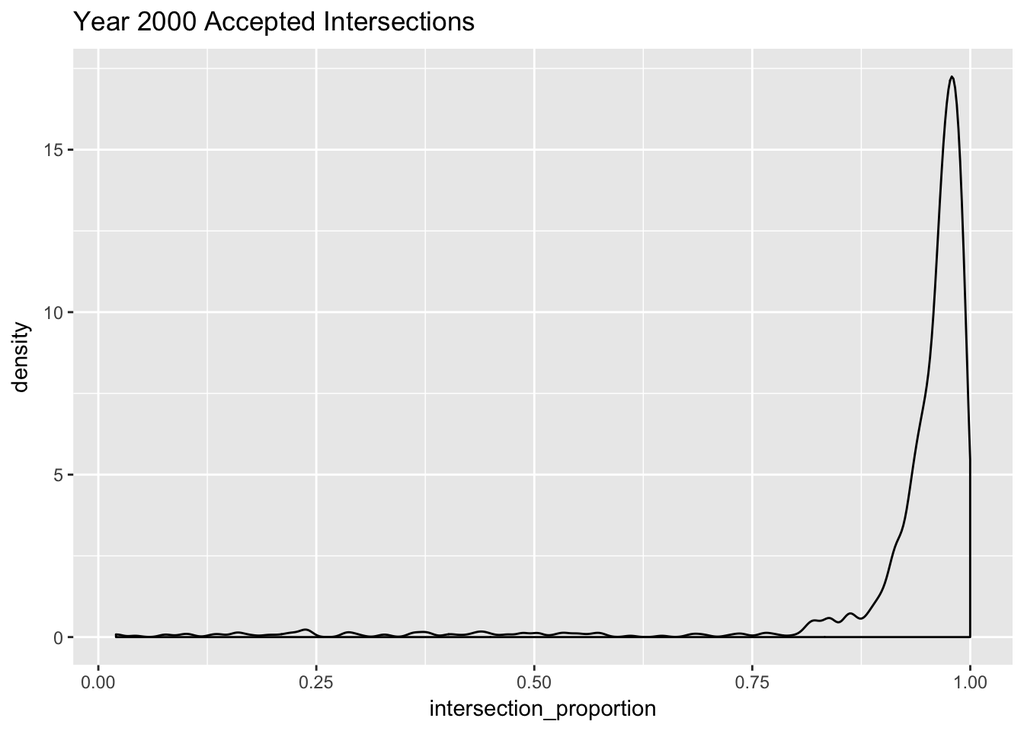

```r
ggplot(replicate_2000_as_sf, aes(intersection_proportion)) +
  geom_density() +
  labs(title = "Year 2000 Accepted Intersections")
```

It seems like the proportion of intersection is a good starting point.

However, it may also be useful to consider area for some edge cases.

Lets look at the rejected intersections from Year 2000 with a high proportion of intersection.

## Cartographic review of Proportions used in Year 2000 Data

```r
rejected_more_than_10 <- (slivers_2000_as_sf[slivers_2000_as_sf$intersection_proportion>.10,])

topojson_write(rejected_more_than_10 ,file="rejected_more_than_10.topojson",convert_wgs84 = TRUE)
## Success! File at rejected_more_than_10.topojson
## <topojson-file>
##   Path:       rejected_more_than_10.topojson
##   From class: sfc

accepted_less_than_75 <- (slivers_2000_as_sf[replicate_2000_as_sf$intersection_proportion<.75,])

topojson_write(accepted_less_than_75 ,file="accepted_less_than_75.topojson",convert_wgs84 = TRUE)
## Success! File at accepted_less_than_75.topojson
## <topojson-file>
##   Path:       accepted_less_than_75.topojson
##   From class: sfc
```

Click [here](https://github.com/BayAreaMetro/Data-And-Visualization-Projects/blob/master/census_examples/accepted_less_than_75.topojson) to see the TAZ/Tract intersections from Year 2000 that were accepted but had less than 75% of an area of the tract they were matched to.

Click [here](https://github.com/BayAreaMetro/Data-And-Visualization-Projects/blob/master/census_examples/rejected_more_than_10.topojson) to see the TAZ/Tract intersections from Year 2000 that were jeceted but had more than 10% of an area of the tract they were matched to.